# Python Programlama Dili (Devam)

## Liste kullanım uygulamarı

```python
# bir elemanın listedeki sıra numarası
# baştan itiraben sayılmaya başlandığında
#         0  1  2  3  4  5  6  7  8   9
liste1 = [1, 2, 3, 4, 5, 6, 7, 8, 9, 10]

# sondan başa doğru sayılırsa
#       -10 -9 -8 -7 -6 -5 -4 -3 -2  -1
liste1 = [1, 2, 3, 4, 5, 6, 7, 8, 9, 10]
```

```python
type(liste1)
```

```
list
```

```python
# boş liste de oluşturulabilir.
bos_liste = []
type(bos_liste)
```

```
list
```

```python
# aşağıdaki gibi index metodu kullanılarak bir listeye
# ait elamanın listedeki sıra numarası elde edilebilir.
liste1.index(10)
```

```
9
```

```python
liste2 = [1, 2, 3, 4, 5, 1000, 6, 7, 8, 9, 1000]
```

```python
# aynı değere sahip iki eleman varsa ilk karşılaştığı
# elamanın sıra numarasını verir.
liste2.index(1000)
```

```
5
```

```python
# listeye ait olmayan bir eleman sorgulanırsa
# ValueError: (value) is not in list
# hatası verir. Anlamı bu değer listede yok!
liste2.index(11)
```

```
---------------------------------------------------------------------------
ValueError                                Traceback (most recent call last)
<ipython-input-7-311d26d08e22> in <module>
      2 # ValueError: (value) is not in list
      3 # hatası verir. Anlamı bu değer listede yok!
----> 4 liste2.index(11)

ValueError: 11 is not in list
```

```python
# count metodu ile bir listede ilgilendiğimiz bir elemandan
# kaç tane var onu öğrenebiliriz.
liste2.count(1000)
```

```
2
```

```python
# clear metoduyla bütün liste elemanları silinir ve
# liste boş liste halini alır.
liste2.clear()
```

```python
# list komutunu kullanarak aşağıdaki gibi
# bir liste oluşturmak mümkündür.
liste2 = list("Mesut Karakoç")
print(liste2)
```

```
['M', 'e', 's', 'u', 't', ' ', 'K', 'a', 'r', 'a', 'k', 'o', 'ç']
```

```python
# listenin sıralamasını reverse metoduyla
# ters çevirmek mümkündür.
liste2.reverse()
print(liste2)
```

```
['ç', 'o', 'k', 'a', 'r', 'a', 'K', ' ', 't', 'u', 's', 'e', 'M']
```

```python
# copy metoduyla bir listenin aynısından
# yeni bir tane oluşturmak mümkündür.
liste3 = liste2.copy()
print(liste3)
```

```
['ç', 'o', 'k', 'a', 'r', 'a', 'K', ' ', 't', 'u', 's', 'e', 'M']
```

```python
# aşağıdaki uygulamayla listenin yeni bir kopyası OLUŞMAZ!!!
# liste2 ve yeni değişken liste4 aynı LİSTE nesnesine bakmaktadır.
liste4 = liste2
```

```python
# liste2'nin 0. elamanını değiştirmeden önce
print(liste2[0])
print(liste4[0])
```

```
ç
ç
```

```python
# liste2'nin 0. elamanını değiştirdik.
liste2[0] = "A"
print(liste2[0])
```

```
A
```

```python
# liste4 değişkeni aynı liste nesnesine baktığı için
# liste4[0] yeni değeri göstermektedir.
print(liste4[0])
```

```
A
```

```python
print(liste3[0])
```

```
ç
```

```python
# remove'la istenilen bir eleman silinebilir.
liste2.remove('a')
```

```python
# listemizin son hali
liste2
```

```
['A', 'o', 'k', 'r', 'a', 'K', ' ', 't', 'u', 's', 'e', 'M']
```

```python
# listedeki elamanları sıralar, kendine ait bir algoritmayla.
liste2.sort()
print(liste2)
```

```
[' ', 'A', 'K', 'M', 'a', 'e', 'k', 'o', 'r', 's', 't', 'u']
```

```python
# verdiğimiz indeks numarasındaki sıraya göre
# verdiğimiz nesneyi yerleştirir.
liste2.insert(1, "mesut")
```

```python
print(liste2)
```

```
[' ', 'mesut', 'A', 'K', 'M', 'a', 'e', 'k', 'o', 'r', 's', 't', 'u']
```

```python
# indeksini verdiğimiz elemanı siler ve
# sildiği elamanın kendisini gösterir.
liste2.pop(1)
```

```
'mesut'
```

```python
print(liste2)
```

```
[' ', 'A', 'K', 'M', 'a', 'e', 'k', 'o', 'r', 's', 't', 'u']
```

```python
# verilen herhangi bir Python nesnesini
# listenin son elemanı olarak ekler.
liste2.append("bir başka şey")
```

```python
liste2
```

```
[' ', 'A', 'K', 'M', 'a', 'e', 'k', 'o', 'r', 's', 't', 'u', 'bir başka şey']
```

```python
# append metodunun eşdeğeri aşağıdaki gibidir
liste2 = liste2 + ['yeni bir şey']
```

```python
print(liste2)
```

```
[' ', 'A', 'K', 'M', 'a', 'e', 'k', 'o', 'r', 's', 't', 'u', 'bir başka şey', 'yeni bir şey']
```

```python
# extend ile bir listenin sonuna bir başka
# listenin elemanları ilave edilebilir.
liste2.extend([1, 2, 3, 4, 5])
```

```python
print(liste2)
```

```
[' ', 'A', 'K', 'M', 'a', 'e', 'k', 'o', 'r', 's', 't', 'u', 'bir başka şey', 'yeni bir şey', 1, 2, 3, 4, 5]
```

### Listeyle başka bazı uygulamalar

```python
type(range(1, 12, 2))
```

```
range
```

```python
liste5 = list(range(1, 12, 2))
print(liste5)
```

```
[1, 3, 5, 7, 9, 11]
```

```python
# listenin bir elamanına aşağıdaki
# gibi sıra numarası kullanılarak ulaşılabilir.
liste5[3]
```

```
7
```

```python
# listeler tersten de sıralıdır.
# Böylece listenin son elamanına
# şu şekilde ulaşılabilir.
liste5[-1]
```

```
11
```

```python
# belirli bir sıra aralığındaklere ulaşım
liste5[2:5]
```

```
[5, 7, 9]
```

```python
# iki liste bir birine (+) işlemcisiyle de eklenebilir.
liste6 = list(range(1,12,2))
liste7 = list(range(0,12,2))
```

```python
print(liste6)
print(liste7)
print(liste6 + liste7)
print(liste7 + liste6)
```

```
[1, 3, 5, 7, 9, 11]
[0, 2, 4, 6, 8, 10]
[1, 3, 5, 7, 9, 11, 0, 2, 4, 6, 8, 10]
[0, 2, 4, 6, 8, 10, 1, 3, 5, 7, 9, 11]
```

### Liste ve döngü içeren bir örnek

```python
# y = x**2'yi hesaplayan bir program

sayi_listesi = list(range(11))
print("listemiz = ", sayi_listesi)

for x in sayi_listesi:
    print(x, x**2)
```

```
listemiz =  [0, 1, 2, 3, 4, 5, 6, 7, 8, 9, 10]
0 0
1 1
2 4
3 9
4 16
5 25
6 36
7 49
8 64
9 81
10 100
```

```python
x = list(range(11))
x2 = []
for xi in x:
    x2 = x2 + [xi**2]

print(x)
print(x2)
```

```
[0, 1, 2, 3, 4, 5, 6, 7, 8, 9, 10]
[0, 1, 4, 9, 16, 25, 36, 49, 64, 81, 100]
```

```python
x = list(range(11))
x2 = []
for xi in x:
    x2.append(xi**2)

print(x)
print(x2)
```

```
[0, 1, 2, 3, 4, 5, 6, 7, 8, 9, 10]
[0, 1, 4, 9, 16, 25, 36, 49, 64, 81, 100]
```

```python
x = list(range(11))
x2 = []
for xi in x:
    print(x2)
    x2 = x2 + [xi**2]


print(x)
print(x2)
```

```
[]
[0]
[0, 1]
[0, 1, 4]
[0, 1, 4, 9]
[0, 1, 4, 9, 16]
[0, 1, 4, 9, 16, 25]
[0, 1, 4, 9, 16, 25, 36]
[0, 1, 4, 9, 16, 25, 36, 49]
[0, 1, 4, 9, 16, 25, 36, 49, 64]
[0, 1, 4, 9, 16, 25, 36, 49, 64, 81]
[0, 1, 2, 3, 4, 5, 6, 7, 8, 9, 10]
[0, 1, 4, 9, 16, 25, 36, 49, 64, 81, 100]
```

```python
x = list(range(11))
y = []
for xi in x:
    y = y + [xi**2]

print(" x  x^2")
for i, xi in enumerate(x):
    print("{:>2d} {:>4d}".format(xi, y[i]))
```

```
 x  x^2
 0    0
 1    1
 2    4
 3    9
 4   16
 5   25
 6   36
 7   49
 8   64
 9   81
10  100
```

### Listeleri kullanarak çizim yapılabilir

Aşağıda $y = x^2$ grafiği görülmektedir.

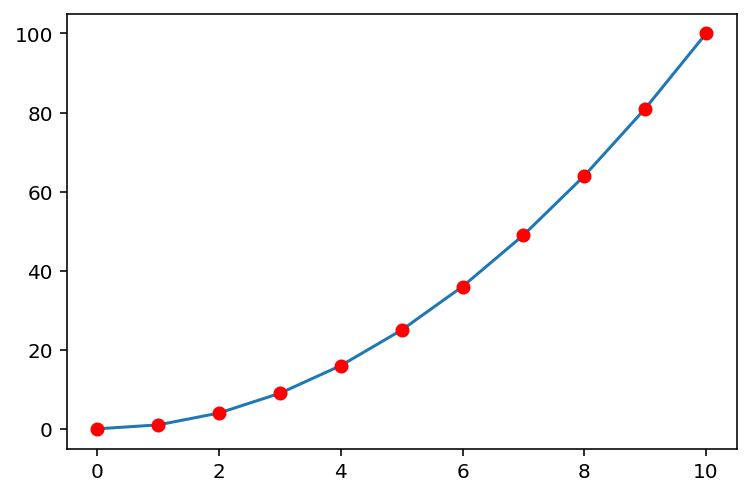

```python
import matplotlib.pyplot as plt
%matplotlib inline

plt.plot(x, y)
plt.plot(x, y, "ro")
plt.show()
```

### Fibonacci sayılarından oluşan seri

```python
n = list(range(16))
Fn = [1, 1]
for ni in n[2:]:
    Fn = Fn + [Fn[-2] + Fn[-1]]

print(" n  Fn")
for ni in n:
    print("{:>2d} {:>3d}".format(ni, Fn[ni]))
```

```
 n  Fn
 0   1
 1   1
 2   2
 3   3
 4   5
 5   8
 6  13
 7  21
 8  34
 9  55
10  89
11 144
12 233
13 377
14 610
15 987
```

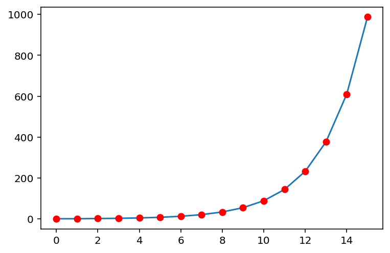

```python
import matplotlib.pyplot as plt
%matplotlib inline

plt.plot(n, Fn)
plt.plot(n, Fn, "ro")
plt.show()
```

```python
print(n)
print(Fn)
```

```
[0, 1, 2, 3, 4, 5, 6, 7, 8, 9, 10, 11, 12, 13, 14, 15]
[1, 1, 2, 3, 5, 8, 13, 21, 34, 55, 89, 144, 233, 377, 610, 987]
```

### Liste kullanmadan Fibonacci sayıları

```python
F0, F1 = 1, 1

for i in range(14):
    F2 = F0 + F1
    F0 = F1
    F1 = F2
    print(F2)
```

```
2
3
5
8
13
21
34
55
89
144
233
377
610
987
```

### List comprehensions (Python'a özel bir liste oluşturma yöntemi)

```python
kare = []
for i in range(1, 11):
    kare.append(i**2)
    #kare = kare + [i**2]

print(kare)
```

```
[1, 4, 9, 16, 25, 36, 49, 64, 81, 100]
```

```python
kare2 = [i**2 for i in range(1,11)]
print(kare2)
```

```
[1, 4, 9, 16, 25, 36, 49, 64, 81, 100]
```

### Python'da Fonksiyon

#### Ürettiği veriyi ana programa aktarmayan fonksiyon örneği

```python
def topla():
    a = 5
    b = 10
    toplam = a + b
    print(a, b, toplam)
```

```python
# a ve b yerel (local) değişkenlerdir.
print(a, b)
```

```
---------------------------------------------------------------------------
NameError                                 Traceback (most recent call last)
<ipython-input-51-0751adecab6e> in <module>
      1 # a ve b yerel (local) değişkenlerdir.
----> 2 print(a, b)

NameError: name 'a' is not defined
```

```python
topla()
```

```
5 10 15
```

```python
print(topla())
```

```
5 10 15
None
```

#### Yerel ve genel değişken örnekleri (Local and Gloal variables)

Python öncelikle varsa yerel değişkeni dikkate alır.

```python
a = 7 # genel değişken
def topla2():
    b = 10 # yerel değişken
    toplam = a + b
    print(a, b, toplam)
```

```python
topla2()
```

```
7 10 17
```

```python
a = 7 # genel değişken
def topla3():
    a = 5 # yerel değişken
    b = 10
    toplam = a + b
    print(a, b, toplam)
```

```python
topla3()
```

```
5 10 15
```

#### Fonksiyonlarda "return" ifadesinin görevi

Bir fonksiyon içinde üretilen veri return ifadesiyle  
ana programa aktarılabilir.

```python
def topla4():
    a = 5
    b = 10
    toplam = a + b
    return toplam
```

```python
topla4()
```

```
15
```

```python
a_ve_b_toplami = topla4()
print(a_ve_b_toplami)
```

```
15
```

#### Fonksiyonlarda parametre kullanımı

```python
def topla5(a, b):
    toplam = a + b
    return toplam
```

```python
topla5(12, 12)
```

```
24
```

#### Fibonacci sayılarını liste olarak üreten bir fonksiyon

```python
def fibonacci(nmax):
    n = list(range(nmax))
    Fn = [1, 1]
    for ni in n[2:]:
        Fn = Fn + [Fn[-2] + Fn[-1]]
    return Fn
```

```python
fibonacci(5)
```

```
[1, 1, 2, 3, 5]
```

```python
def fibonacci2(n0, nmax):
    n = list(range(nmax))
    Fn = [1, 1]
    for ni in n[2:]:
        Fn = Fn + [Fn[-2] + Fn[-1]]
    return Fn[n0:nmax]
```

```python
print(fibonacci2(0, 10))
print(fibonacci2(5, 10))
print(fibonacci2(9, 10))
```

```
[1, 1, 2, 3, 5, 8, 13, 21, 34, 55]
[8, 13, 21, 34, 55]
[55]
```

```python
def fibonacci22(n0, nmax):
    return fibonacci(nmax)[n0:nmax]
```

```python
print(fibonacci22(0, 10))
print(fibonacci22(5, 10))
print(fibonacci22(9, 10))
```

```
[1, 1, 2, 3, 5, 8, 13, 21, 34, 55]
[8, 13, 21, 34, 55]
[55]
```

#### Bir fonksiyonun kullanımı hakkında bilgi verme

```python
def fibonacci3(n0, nmax):
    """
    fibonacci fonksiyonu fibonacci sayılarını hesaplar.
    kullanımı: fibonacci(n0, nmax)
    """
    n = list(range(nmax))
    Fn = [1, 1]
    for ni in n[2:]:
        Fn = Fn + [Fn[-2] + Fn[-1]]
    return Fn[n0:nmax]
```

```python
fibonacci3()
```

```
---------------------------------------------------------------------------
TypeError                                 Traceback (most recent call last)
<ipython-input-70-20d3984f55b0> in <module>
----> 1 fibonacci3()

TypeError: fibonacci3() missing 2 required positional arguments: 'n0' and 'nmax'
```

```python
fibonacci3.__doc__
```

```
'\n    fibonacci fonksiyonu fibonacci sayılarını hesaplar.\n    kullanımı: fibonacci(n0, nmax)\n    '
```

```python
print(fibonacci3.__doc__)
```

```
    fibonacci fonksiyonu fibonacci sayılarını hesaplar.
    kullanımı: fibonacci(n0, nmax)
```

```python
fibonacci3?
```

#### Fonksiyonlarda ön tanımlı parametreler

```python
def fibonacci4(n0=5, nmax=10):
    """
    fibonacci fonksiyonu fibonacci sayılarını hesaplar.
    kullanımı: fibonacci(n0, nmax)
    """
    n = list(range(nmax))
    Fn = [1, 1]
    for ni in n[2:]:
        Fn = Fn + [Fn[-2] + Fn[-1]]
    return Fn[n0:nmax]
```

```python
fibonacci4()
```

```
[8, 13, 21, 34, 55]
```

```python
fibonacci4(3,6)
```

```
[3, 5, 8]
```

```python
fibonacci4(3, nmax=6)
```

```
[3, 5, 8]
```

```python
fibonacci4(n0=3, nmax=6)
```

```
[3, 5, 8]
```

### Python'da Kütüphane Kullanımı

#### numpy kütüphanesi

http://www.numpy.org

nümerik hesaplamalar için gerekli araçları içerir.

#### sympy kütüphanesi

http://www.sympy.org

analitik hesaplamalar için gerekli araçları içerir.

### scipy kütüphanesi

https://www.scipy.org/

çeşitli bilimsel hesaplama araçlarını içerir.

### matplotlib kütüphanesi

https://matplotlib.org/

hesaplanan veya bir şekilde elde edilen verilerin çizimi için kullanılabilir.

### math ve cmath kütüphaneleri

math reel matematik araçlar içerir, cmath ise karmaşık matematik araçlar içerir.

### Kütüphaneleri çağırma yöntemleri

**A) import (kütüphane adı)**

bir kütüphanedeki bütün araçları çağırır

örnek: sympy kütüphanesinden sinüs fonksiyonunu kullanalım.

```python
import sympy

sympy.sin(3.14159)
```

$\displaystyle 2.65358979335273 \cdot 10^{-6}$

```python
sympy.sin(3.14159/2)
```

$\displaystyle 0.99999999999912$

```python
import sympy

print(sympy.sin(3.14159))
print(sympy.sin(sympy.pi))
print(sympy.pi)
print(sympy.N(sympy.pi, 100))
print(str(sympy.N(sympy.pi, 1000))[-1])
```

```
2.65358979335273e-6
0
pi
3.141592653589793238462643383279502884197169399375105820974944592307816406286208998628034825342117068
8
```

**B) import (kütüphane adı) as (kısa/yeni ad)**

```python
import sympy as s

print(s.sin(s.pi))
```

```
0
```

```python
import numpy as np

print(np.sin(np.pi))
```

```
1.2246467991473532e-16
```

```python
np.pi
```

```
3.141592653589793
```

**C) from (kütüphane adı) import $*$**

kütüphanedi bütün araçları çağır

```python
from sympy import *

sin(pi)
```

$\displaystyle 0$

```python
from numpy import *

sin(pi)
```

```
1.2246467991473532e-16
```

**D) from (kütüphane adı) import (araç adı)**

```python
from sympy import cos, pi
```

```python
cos(pi)
```

$\displaystyle -1$

```python
sin(pi)
```

```
---------------------------------------------------------------------------
AttributeError                            Traceback (most recent call last)
AttributeError: 'Pi' object has no attribute 'sin'

The above exception was the direct cause of the following exception:

TypeError                                 Traceback (most recent call last)
<ipython-input-88-69d9a90af4a5> in <module>
----> 1 sin(pi)

TypeError: loop of ufunc does not support argument 0 of type Pi which has no callable sin method
```

**E) from (kütüphane adı) import (araç adı) as (yeni/kısa ad)**

```python
from sympy import cos as c
from sympy import pi
```

```python
c(pi)
```

$\displaystyle -1$

### Uygulama

sin(x) fonksiyonunu $x\in$[0, 4$\pi$] aralağında çizdirelim.

```python
pi = 3.14159

xmin = 0
xmax = 4*pi
nx = 100
dx = (xmax - xmin)/(nx-1)

xlist = []
for i in range(nx):
    #xlist.append(xmin + i*dx)
    xlist = xlist + [xmin + i*dx]
```

```python
from numpy import sin

ylist = []
for xi in xlist:
    ylist = ylist + [sin(xi)]
```

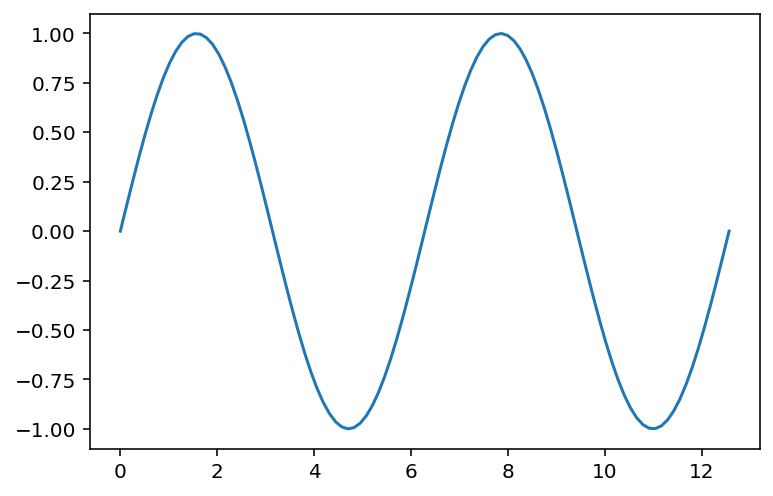

```python
import matplotlib.pyplot as plt
%matplotlib inline

plt.plot(xlist, ylist)
plt.show()
```

### Yukarıdaki süreci tek bir hücrede de halledebiliriz.

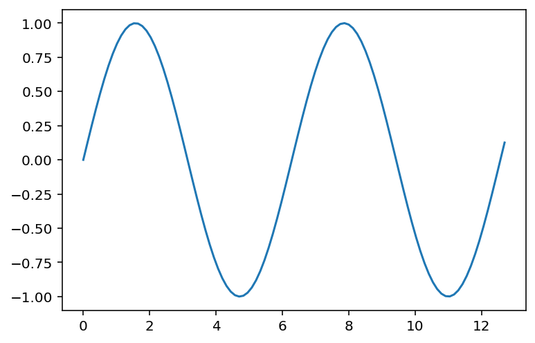

```python
from numpy import sin
import matplotlib.pyplot as plt
%matplotlib inline

pi = 3.14159

xmin = 0
xmax = 4 * pi
nx = 100
dx = (xmax - xmin)/(nx-1)

xlist = []
for i in range(nx+1):
    #xlist.append(xmin + i*dx)
    xlist = xlist + [xmin + i*dx]

ylist = []
for xi in xlist:
    ylist = ylist + [sin(xi)]

plt.plot(xlist, ylist)
plt.show()
```

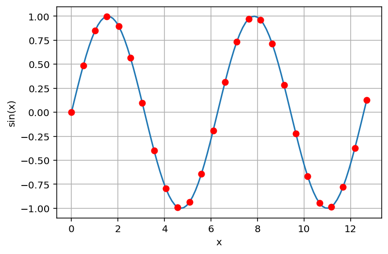

```python
from numpy import sin
import matplotlib.pyplot as plt
%matplotlib inline

pi = 3.14159

xmin = 0
xmax = 4 * pi
nx = 100
dx = (xmax - xmin)/(nx-1)

xlist = []
for i in range(nx+1):
    #xlist.append(xmin + i*dx)
    xlist = xlist + [xmin + i*dx]

ylist = []
for xi in xlist:
    ylist = ylist + [sin(xi)]

plt.plot(xlist, ylist)

plt.plot(xlist[::4], ylist[::4], 'ro')

plt.xlabel('x')
plt.ylabel('sin(x)')
plt.grid()
plt.show()
```

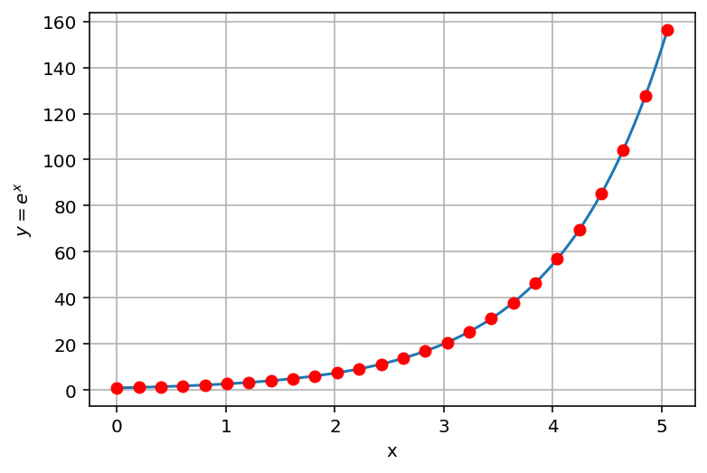

```python
from numpy import exp
import matplotlib.pyplot as plt
%matplotlib inline

xmin = 0
xmax = 5
nx = 100
dx = (xmax - xmin)/(nx-1)

xlist = []
for i in range(nx+1):
    #xlist.append(xmin + i*dx)
    xlist = xlist + [xmin + i*dx]

ylist = []
for xi in xlist:
    ylist = ylist + [exp(xi)]

plt.plot(xlist, ylist)

plt.plot(xlist[::4], ylist[::4], 'ro')

plt.xlabel('x')
plt.ylabel('$y = e^x$')

plt.grid()
plt.show()
```

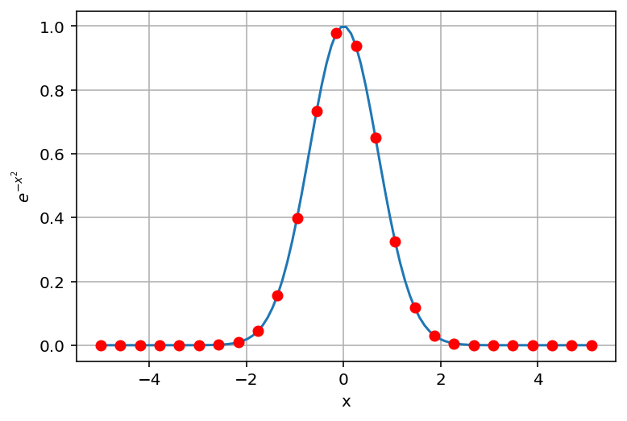

```python
from numpy import exp
import matplotlib.pyplot as plt
%matplotlib inline

xmin = -5
xmax = 5
nx = 100
dx = (xmax - xmin)/(nx-1)

xlist = []
for i in range(nx+1):
    #xlist.append(xmin + i*dx)
    xlist = xlist + [xmin + i*dx]

ylist = []
for xi in xlist:
    ylist = ylist + [exp(-xi**2)]

plt.plot(xlist, ylist)
plt.plot(xlist[::4], ylist[::4], 'ro')
plt.xlabel('x')
plt.ylabel('$e^{-x^2}$')
plt.grid()
plt.show()
```

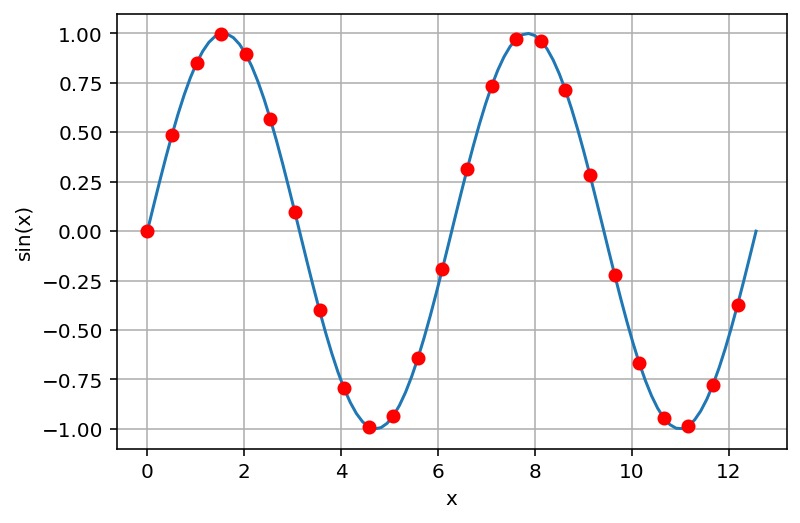

```python
import numpy as np
import matplotlib.pyplot as plt
%matplotlib inline

xmin = 0
xmax = 4*np.pi
nx = 100

xlist = np.linspace(xmin, xmax, nx)
ylist = np.sin(xlist)

plt.plot(xlist, ylist)
plt.plot(xlist[::4], ylist[::4], 'ro')
plt.xlabel('x')
plt.ylabel('sin(x)')
plt.grid()
plt.show()
```

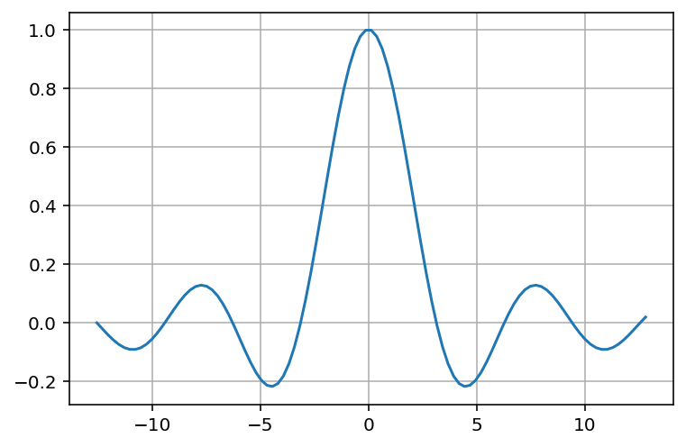

```python
from numpy import sin, cos, sqrt, pi
import matplotlib.pyplot as plt
%matplotlib inline

xmin = -4*pi
xmax = 4*pi
nx = 100
dx = (xmax - xmin)/(nx-1)

xlist = []
for i in range(nx+1):
    xlist = xlist + [xmin + i*dx]

ylist = []
for xi in xlist:
    ylist = ylist + [sin(xi)/xi]

plt.plot(xlist, ylist)
plt.grid()
plt.show()
```

### Rastgele (Random) sayıları elde etme

```python
import random as rnd

# 0 ile 1 aralığında
# sözde rastgele sayı üretir
rnd.random()
```

```
0.9848828557531956
```

```python
# 0 ile 10 aralığında rastgele
# sayı elde etme
10*rnd.random()
```

```
9.351183993231606
```

```python
# 1 ile 100 aralığında rastgele
# tam sayı elde etme
rnd.randint(1, 100)
```

```
91
```

### Monte Carlo yöntemiyle $\pi$ sayısı hesabı

https://tr.wikipedia.org/wiki/Monte_Carlo_benzetimi

Monte Carlo benzetimi. Rastgele üretilen sayılardan faydalanılarak istatistiksel simülasyonlar Monte Carlo metoduyla yapılır. Monte-Carlo Nicholas Constantine Metropolis (1915-1999) tarafından bulunmuştur ve Atom bombasının geliştirildiği Los Alamos Ulusal Labratuvarında, bombanın patlamasından sonra dağılan nötronlara karşı kalkan modellemek için Stanislaw Ulam tarafından günümüze taşınmıştır.

Deney girdileri belirli olmayan, kesin olmayan bir şekilde gelmesi bekleniyorsa ve dağılım bir fonksiyonla hesaplanabilecekse kullanılır. Monte Carlo, rastgele sayıları baz alarak tahmini sistemleri modeller. Hücre Similasyonu, Borsa Modelleri, Dağılım Fonksiyonları, Sayısal Analiz, Doğal olayların simülasyonu, Atom ve Molekül Fiziği, Nükleer Fizik ve Yüksek Enerji Fiziği modellerini test eden simülasyonlar, Deneylerde kullanılan aletlerin simülasyonu (Örneğin bir madde içerisinde x ışınlarının dağılımı).

Yukarıdaki modellerde tahminler yapabilmek için; Rastgele sayı üretilir, bunun için programlama bilgisi gerekmektedir.

```python
import numpy as np
import random as rnd
import matplotlib.pyplot as plt
%matplotlib inline

r = 2 # daire yarı çapı
atis = 1000

def mnc(x):
    return (-1)**rnd.randint(1,10) * x*rnd.random()

xlist = [mnc(r) for i in range(atis)]
ylist = [mnc(r) for i in range(atis)]

# dairenin içinde kalanları sayalım
daire = 0
for i in range(atis):
    ri = (xlist[i]**2 + ylist[i]**2)**.5
    if ri<=r:
        daire = daire + 1

pi_sayisi = 4*daire/atis

print(pi_sayisi)
```

```
3.104
```

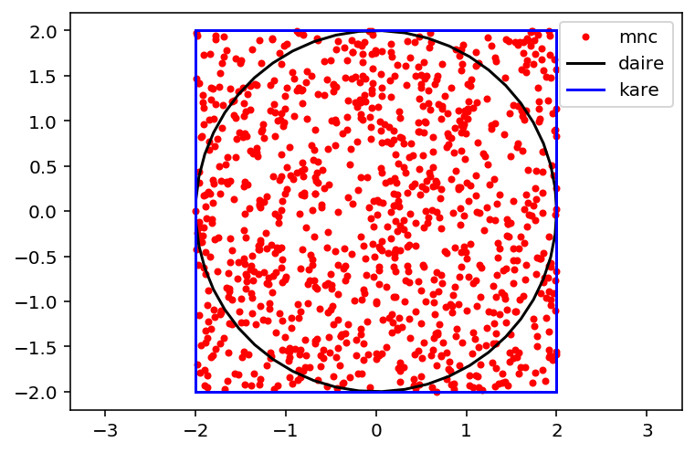

```python
theta = np.linspace(0, 2*np.pi)
xd = r*np.cos(theta)
yd = r*np.sin(theta)

plt.plot(xlist, ylist, 'r.', label='mnc')

plt.plot(xd, yd, color="black", label='daire')

plt.plot([-r, -r], [-r, r], color="blue", label='kare')
plt.plot([-r, r], [r, r], color="blue")
plt.plot([r, r], [r, -r], color="blue")
plt.plot([r, -r], [-r, -r], color="blue")

plt.axis('equal')
plt.legend(loc='best')
plt.show()
```